# R Genomics: factors and data frames

# R Basics continued - factors and data frames

Working with spreadsheets (tabular data)

Importing tabular data into R

There are several ways to import data into R.

For our purpose here, we will focus on using the tools every R installation comes with (so called “base” R)

to import a comma-delimited file containing the results of our variant calling workflow.

We will need to load the sheet using a function called read.csv().

```r
?read.csv()
```

Now, let’s read in the file combined_tidy_vcf.csv

```r
# read in a CSV file and save it as 'variants'
variants <- read.csv("../rawdata/combined_tidy_vcf.csv")
```

Use View() function to bring up inbuilt data frame viewer

```r
View(variants)
```

## Summarizing and determining the structure of a data frame.

A data frame is the standard way in R to store tabular data.

A data fame could also be thought of as a collection of vectors, all of which have the same length.

Using only two functions, we can learn a lot about out data frame

including some summary statistics as well as well as the “structure” of the data frame.

Let’s examine what each of these functions can tell us:

```r
#summary(variants)
```

skim it

```r
skimr::skim(variants)
```

|  | variable | type | stat | level | value | formatted |
| --- | --- | --- | --- | --- | --- | --- |
| 1 | sample_id | factor | missing | .all | 0.000000e+00 | 0 |
| 2 | sample_id | factor | complete | .all | 8.010000e+02 | 801 |
| 3 | sample_id | factor | n | .all | 8.010000e+02 | 801 |
| 4 | sample_id | factor | n_unique | .all | 3.000000e+00 | 3 |
| 5 | sample_id | factor | top_counts | SRR2584866 | 7.660000e+02 | SRR: 766 |
| 6 | sample_id | factor | top_counts | SRR2584863 | 2.500000e+01 | SRR: 25 |
| 7 | sample_id | factor | top_counts | SRR2589044 | 1.000000e+01 | SRR: 10 |
| 8 | sample_id | factor | top_counts | NA | 0.000000e+00 | NA: 0 |
| 9 | sample_id | factor | ordered | .all | 0.000000e+00 | FALSE |
| 10 | CHROM | factor | missing | .all | 0.000000e+00 | 0 |

[output cut: 844 more lines]

Before we operate on the data, we also need to know a little more about the data frame structure to do that we use the str() function:

```r
str(variants)
```

```
## 'data.frame':    801 obs. of  29 variables:
##  $ sample_id    : Factor w/ 3 levels "SRR2584863","SRR2584866",..: 1 1 1 1 1 1 1 1 1 1 ...
##  $ CHROM        : Factor w/ 1 level "CP000819.1": 1 1 1 1 1 1 1 1 1 1 ...
##  $ POS          : int  9972 263235 281923 433359 473901 648692 1331794 1733343 2103887 2333538 ...
##  $ ID           : logi  NA NA NA NA NA NA ...
##  $ REF          : Factor w/ 59 levels "A","ACAGCCAGCCAGCCAGCCAGCCAGCCAGCCAG",..: 49 33 33 30 24 16 16 33 2 12 ...
##  $ ALT          : Factor w/ 57 levels "A","AC","ACAGCCAGCCAGCCAGCCAGCCAGCCAGCCAGCCAG",..: 31 46 46 29 25 46 1 1 4 15 ...
##  $ QUAL         : num  91 85 217 64 228 210 178 225 56 167 ...
##  $ FILTER       : logi  NA NA NA NA NA NA ...
##  $ INDEL        : logi  FALSE FALSE FALSE TRUE TRUE FALSE ...
##  $ IDV          : int  NA NA NA 12 9 NA NA NA 2 7 ...
##  $ IMF          : num  NA NA NA 1 0.9 ...
##  $ DP           : int  4 6 10 12 10 10 8 11 3 7 ...
##  $ VDB          : num  0.0257 0.0961 0.7741 0.4777 0.6595 ...
##  $ RPB          : num  NA 1 NA NA NA NA NA NA NA NA ...
##  $ MQB          : num  NA 1 NA NA NA NA NA NA NA NA ...
##  $ BQB          : num  NA 1 NA NA NA NA NA NA NA NA ...
##  $ MQSB         : num  NA NA 0.975 1 0.916 ...
##  $ SGB          : num  -0.556 -0.591 -0.662 -0.676 -0.662 ...
##  $ MQ0F         : num  0 0.167 0 0 0 ...
##  $ ICB          : logi  NA NA NA NA NA NA ...
##  $ HOB          : logi  NA NA NA NA NA NA ...
##  $ AC           : int  1 1 1 1 1 1 1 1 1 1 ...
##  $ AN           : int  1 1 1 1 1 1 1 1 1 1 ...
##  $ DP4          : Factor w/ 217 levels "0,0,0,2","0,0,0,3",..: 3 132 73 141 176 104 61 74 133 137 ...
##  $ MQ           : int  60 33 60 60 60 60 60 60 60 60 ...
##  $ Indiv        : Factor w/ 3 levels "/home/dcuser/dc_workshop/results/bam/SRR2584863.aligned.sorted.bam",..: 1 1 1 1 1 1 1 1 1 1 ...
##  $ gt_PL        : Factor w/ 206 levels "100,0","103,0",..: 16 10 134 198 142 127 93 142 9 80 ...
##  $ gt_GT        : int  1 1 1 1 1 1 1 1 1 1 ...
##  $ gt_GT_alleles: Factor w/ 57 levels "A","AC","ACAGCCAGCCAGCCAGCCAGCCAGCCAGCCAGCCAG",..: 31 46 46 29 25 46 1 1 4 15 ...
```

## Introducing Factors

Factors are the final major data structure we will introduce in our R genomics lessons.

Factors can be thought of as vectors which are specialized for categorical data.

## subset the “REF” column to a new object

```r
REF <- variants$REF
```

Let’s look at the first few items in our factor using head():

```r
head(REF)
```

```
## [1] T        G        G        CTTTTTTT CCGC     C
## 59 Levels: A ACAGCCAGCCAGCCAGCCAGCCAGCCAGCCAG ACCCC ACCCCCCC ... TGGGGGGG
```

```r
str(REF)
```

```
##  Factor w/ 59 levels "A","ACAGCCAGCCAGCCAGCCAGCCAGCCAGCCAG",..: 49 33 33 30 24 16 16 33 2 12 ...
```

# Plotting

One of the most common uses for factors will be when you plot categorical values. For example, suppose we want to know how many of our variants had each possible nucleotide (or nucleotide combination) in the reference genome? We could generate a plot:

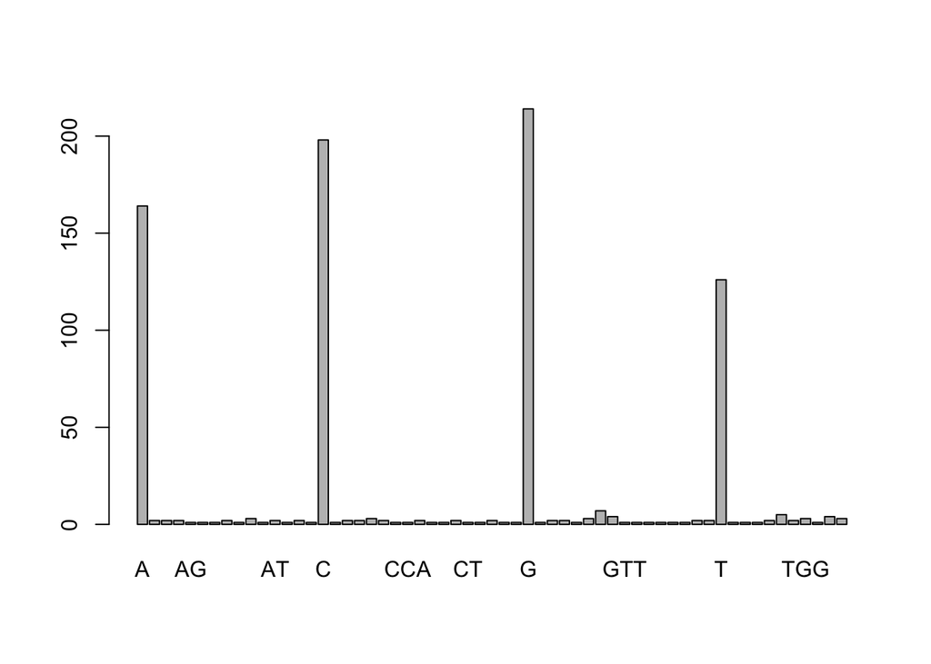

```r
plot(REF)
```

extra (forcats )[https://forcats.tidyverse.org/]

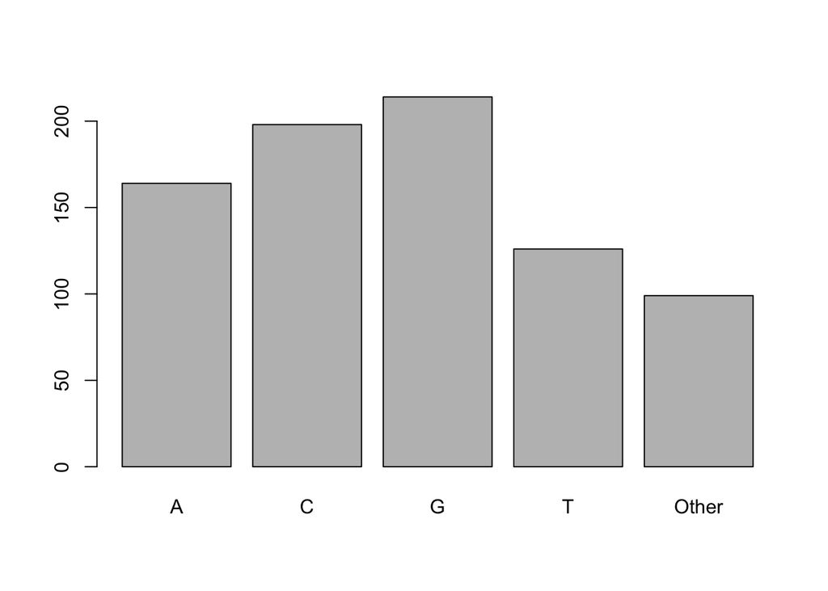

```r
plot(forcats::fct_lump(REF,n=4))
```

## Subsetting data frames

Next, we are going to talk about how you can get specific values from data frames,

and where necessary, change the mode of a column of values.

The subsetting notation is very similar to what we learned for vectors.

The key differences include:

Typically provide two values separated by commas: data.frame[row, column]

variants[1,1]

In cases where you are taking a continuous range of numbers use a colon between the numbers (start:stop, inclusive)

variants[1:5,1:5]

For a non continuous set of numbers, pass a vector using c() variants[c(1,4,9),1:5]

Index using the name of a column(s) by passing them as vectors using c() variants[1:5,c(“POS”)]

Finally, in all of the subsetting exercises above, we printed values to the screen. You can create a new data frame object by assigning them to a new object name

# create a new data frame from variants object containing only observations from sample_id SRR2584863

```r
SRR2584863_variants <-variants[variants$sample_id=="SRR2584863",]
```

check the dimension of the data frame ?dim()

```r
dim(SRR2584863_variants)
```

```
## [1] 25 29
```

## get a summary of the data frame ?summary()

```r
summary(SRR2584863_variants)
```

```
##       sample_id         CHROM         POS             ID
##  SRR2584863:25   CP000819.1:25   Min.   :   9972   Mode:logical
##  SRR2584866: 0                   1st Qu.:1331794   NA's:25
##  SRR2589044: 0                   Median :2618472
##                                  Mean   :2464989
##                                  3rd Qu.:3488669
##                                  Max.   :4616538
##
##                                REF
##  A                               :10
##  G                               : 6
##  C                               : 3
##  ACAGCCAGCCAGCCAGCCAGCCAGCCAGCCAG: 1
##  AT                              : 1
##  CCGC                            : 1
##  (Other)                         : 3
##                                                        ALT
##  T                                                       :7
##  C                                                       :6
##  A                                                       :4
##  G                                                       :3
##  AC                                                      :1
##  ACAGCCAGCCAGCCAGCCAGCCAGCCAGCCAGCCAGCCAGCCAGCCAGCCAGCCAG:1
##  (Other)                                                 :3
##       QUAL         FILTER          INDEL              IDV
##  Min.   : 31.89   Mode:logical   Mode :logical   Min.   : 2.00
##  1st Qu.:104.00   NA's:25        FALSE:19        1st Qu.: 3.25
##  Median :211.00                  TRUE :6         Median : 8.00
##  Mean   :172.97                                  Mean   : 7.00
##  3rd Qu.:225.00                                  3rd Qu.: 9.75
##  Max.   :228.00                                  Max.   :12.00
##                                                  NA's   :19
##       IMF               DP            VDB               RPB
##  Min.   :0.6667   Min.   : 2.0   Min.   :0.01627   Min.   :0.9008
##  1st Qu.:0.9250   1st Qu.: 9.0   1st Qu.:0.07140   1st Qu.:0.9275
##  Median :1.0000   Median :10.0   Median :0.37674   Median :0.9542
##  Mean   :0.9278   Mean   :10.4   Mean   :0.40429   Mean   :0.9517
##  3rd Qu.:1.0000   3rd Qu.:12.0   3rd Qu.:0.65951   3rd Qu.:0.9771
##  Max.   :1.0000   Max.   :20.0   Max.   :0.99604   Max.   :1.0000
##  NA's   :19                                        NA's   :22
```

[output cut: 33 more lines]

```
##  255,0  :11   Min.   :1
##  111,28 : 1   1st Qu.:1
##  112,0  : 1   Median :1
##  121,0  : 1   Mean   :1
##  131,0  : 1   3rd Qu.:1
##  194,0  : 1   Max.   :1
##  (Other): 9
##                                                   gt_GT_alleles
##  T                                                       :7
##  C                                                       :6
##  A                                                       :4
##  G                                                       :3
##  AC                                                      :1
##  ACAGCCAGCCAGCCAGCCAGCCAGCCAGCCAGCCAGCCAGCCAGCCAGCCAGCCAG:1
##  (Other)                                                 :3
```

#coercion #StringsAsFactors = FALSE

## Data frame bonus material: math, sorting, renaming

You can use functions like

mean() min() max()

on an individual column.

Find maximum depth, DP, of all variants

```r
max(variants$DP)
```

```
## [1] 79
```

You can sort a data frame using the order() function:

Sort variants data frame by DP

```r
sorted_by_DP <- variants[order(variants$DP), ]
head(sorted_by_DP$DP)
```

```
## [1] 2 2 2 2 2 2
```

You can rename columns: ?colnames

Rename column sample_id to strain

```r
colnames(variants)[colnames(variants) == "sample_id"] <- "strain"
```

check the column name (hint names are returned as a vector)

```r
colnames(variants)
```

```
##  [1] "strain"        "CHROM"         "POS"           "ID"
##  [5] "REF"           "ALT"           "QUAL"          "FILTER"
##  [9] "INDEL"         "IDV"           "IMF"           "DP"
## [13] "VDB"           "RPB"           "MQB"           "BQB"
## [17] "MQSB"          "SGB"           "MQ0F"          "ICB"
## [21] "HOB"           "AC"            "AN"            "DP4"
## [25] "MQ"            "Indiv"         "gt_PL"         "gt_GT"
## [29] "gt_GT_alleles"
```

## Saving your data frame to a file

?write.csv() ?file.path()

```r
write.csv(x = SRR2584863_variants, file = file.path("../","data","SRR2584863_variants.csv"))
```

# Key Points

- It is easy to import data into R from tabular formats However, you still need to check that R has imported and interpreted your data correctly

There are best practices for organizing your data (keeping it tidy) and R is great for this Base R has many useful functions for manipulating your data, but all of R’s capabilities are greatly enhanced by software packages developed by the community

Swirl exercises data frames and factors